# Practical ggplot2

### The grammar of graphics: Facets

##### data / mapping / statistics / scales / geometries / **FACETS** / coordinates / theme

- Facets divide a plot into subplots based on the values of one or more discrete values.
- It is a good way to avoid overplotting.
- They should not be used to combine separate plots. You may wish to have multiple plotting areas. It is the layout of your subplots and the layout may have some meaning.

```r
# ~ take the value and map to panel
```

### The grammar of graphics: Coordinates

##### data / mapping / statistics / scales / geometries / facets / **COORDINATES** / theme

- the coordinate system modifies the x and y values The scaled positions are passed through the coordinate system. You often don’t think about it as we are used to the using the cartesian coordinate system but if you work in mapping you will be more familiar with other coordinate systems. It is specific to positional asethetic.
- limits and transformation can be applied in scale or in coord
  - scale will apply it in the beginning
  - coord will apply it at the end
  - you usually want coord if you want to update axses. If you limit the axis with scale it will remove values outside of your scale, whereas if you scale with coord_cartesian you are propertly zooming - you are not affecting the date
- it changes how the data is being drawn
- used in cartography (many ways of transforming longitudes and latitudes)

Other coordinate systems - coord_cartesian: most plots are drawn in a cartesian coordinate system - coord_polar: x and y as radius and angle

### The grammar of graphics: Theme

##### data / mapping / statistics / scales / geometries / facets / coordinates / **THEME**

- Stylistic changes to the plot not related to the data.
- In ggplot2 theme() is hierarchical in nature
- Part 2 of the workshop covers theme() in detail.

## Part 2: Designing a consistent design style using theme()

> **Why focus on styling?** Decision making is the key competency in data visualisation. We need to make effective decisions efficiently. We can use a design process to facilitate effective decision making and we can adopt a standard theme, based upon good design principals, to streamline the final presentation work.

### `theme()` arguments

```r
# this code will not run
theme(
  line,
  rect,
  text,
  title,
  aspect.ratio,
  axis.title,
  axis.title.x,
  axis.title.x.top,
  axis.title.x.bottom,
  axis.title.y,
  axis.title.y.left,
  axis.title.y.right,
  axis.text,
  axis.text.x,
  axis.text.x.top,
  axis.text.x.bottom,
  axis.text.y,
  axis.text.y.left,
  axis.text.y.right,
  axis.ticks,
  axis.ticks.x,
  axis.ticks.x.top,
  axis.ticks.x.bottom,
  axis.ticks.y,
  axis.ticks.y.left,
  axis.ticks.y.right,
  axis.ticks.length,
  axis.ticks.length.x,
  axis.ticks.length.x.top,
  axis.ticks.length.x.bottom,
  axis.ticks.length.y,
  axis.ticks.length.y.left,
  axis.ticks.length.y.right,
  axis.line,
  axis.line.x,
  axis.line.x.top,
  axis.line.x.bottom,
  axis.line.y,
  axis.line.y.left,
  axis.line.y.right,
  legend.background,
  legend.margin,
  legend.spacing,
  legend.spacing.x,
  legend.spacing.y,
  legend.key,
  legend.key.size,
  legend.key.height,
  legend.key.width,
  legend.text,
  legend.text.align,
  legend.title,
  legend.title.align,
  legend.position,
  legend.direction,
  legend.justification,
  legend.box,
  legend.box.just,
  legend.box.margin,
  legend.box.background,
  legend.box.spacing,
  panel.background,
  panel.border,
  panel.spacing,
  panel.spacing.x,
  panel.spacing.y,
  panel.grid,
  panel.grid.major,
  panel.grid.minor,
  panel.grid.major.x,
  panel.grid.major.y,
  panel.grid.minor.x,
  panel.grid.minor.y,
  panel.ontop,
  plot.background,
  plot.title,
  plot.title.position,
  plot.subtitle,
  plot.caption,
  plot.caption.position,
  plot.tag,
  plot.tag.position,
  plot.margin,
  strip.background,
  strip.background.x,
  strip.background.y,
  strip.placement,
  strip.text,
  strip.text.x,
  strip.text.y,
  strip.switch.pad.grid,
  strip.switch.pad.wrap,
  ...,
  complete = FALSE,
  validate = TRUE
)
```

### Element functions

`theme()` constructs plots as a combination of:

- Rectangles
- Lines
- Text
- Empty space

The `element_` functions specify the display of how non-data components of the plot are drawn.

- `element_blank()` draws nothing, and assigns no space
- `element_rect()` borders and backgrounds
- `element_line()` lines
- `element_text()` text

### Rectangles

`element_rect()`

```r
# this code will not run
element_rect(
  fill = NULL,
  colour = NULL,
  size = NULL,
  linetype = NULL,
  color = NULL,
  inherit.blank = FALSE
)
```

- plot background
- panel background
- legend.key
- legend background
- legend box background

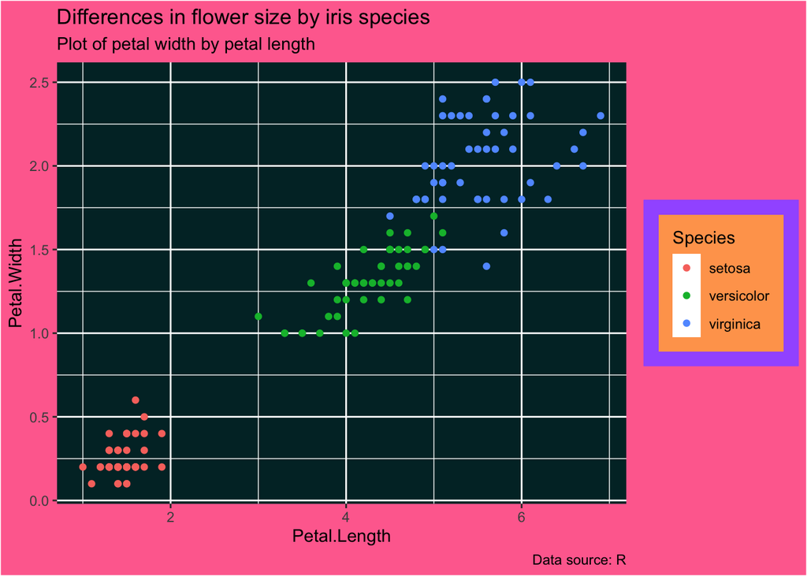

```r
# Colours
  dark_green <- "#002D30"
  light_grey <- "#F2F2F2"
  green_blue <- "#007883"
  light_green <- "#4FE18F"
  blue <- "#00C3D6"
  pink <- "#FF709D"
  purple <- "#A361FF"
  orange <- "#ffa45a"
# Font
#  font <- "Derailed"

# The plot
ggplot(data = iris) +
  geom_point(mapping = aes(x = Petal.Length, y = Petal.Width, colour = Species)) +
  labs(title = "Differences in flower size by iris species",
       subtitle = "Plot of petal width by petal length",
       caption = "Data source: R") +

  # Theme
  theme(
    # You can use this to remove all lines from the plot
    #rect = element_blank(),

    # Plot rectangle format:
    plot.background = element_rect(fill = pink),

    # Panel rectangle format:
    panel.background = element_rect(fill = dark_green),
    #panel.border = element_rect(fill = light_grey, colour = pink), # you probably will never need to use this

    legend.key = element_rect(fill = "white"),
    legend.background = element_rect(fill = orange),
    legend.margin = margin(9,9,9,9),

    legend.box.background = element_rect(fill = purple, colour = purple),
    legend.box.margin = margin(9,9,9,9),
    )
```

### Lines

`element_line()`

```r
# this code will not run
element_line(
   colour = NULL,
   size = NULL,
   linetype = NULL,
   lineend = NULL,
   color = NULL,
   arrow = NULL,
   inherit.blank = FALSE
)
```

- axis ticks
- axis line x
- axis line y
- panel grid minor
- panel grid major

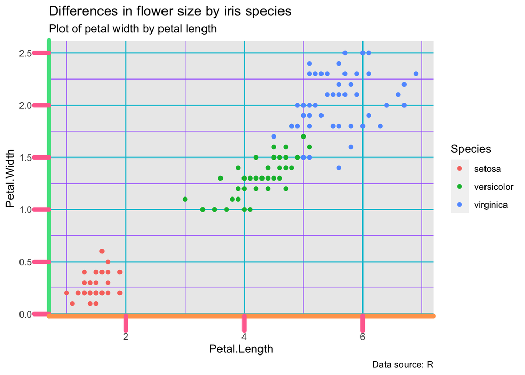

```r
# Colours
  dark_green <- "#002D30"
  light_grey <- "#F2F2F2"
  green_blue <- "#007883"
  light_green <- "#4FE18F"
  blue <- "#00C3D6"
  pink <- "#FF709D"
  purple <- "#A361FF"
  orange <- "#ffa45a"
# Font
#  font <- "Derailed"

# The plot
ggplot(data = iris) +
  geom_point(mapping = aes(x = Petal.Length, y = Petal.Width, colour = Species)) +
  labs(title = "Differences in flower size by iris species",
       subtitle = "Plot of petal width by petal length",
       caption = "Data source: R") +

  # Theme
  theme(
    # You can use this to remove all lines from the plot
    #line = element_blank(),

    # Update the axis ticks
    axis.ticks = element_line(colour = pink, lineend = "round", size = 2),
    axis.ticks.length = unit(.5, "cm"),

    # Update the axis lines
    axis.line.x = element_line(colour = orange, lineend = "round", size = 2),
    axis.line.y = element_line(colour = light_green, lineend = "round", size = 2),

    # Update the grid lines
    #panel.grid = element_line(colour = pink),
    panel.grid.minor = element_line(colour = purple),
    panel.grid.major = element_line(colour = blue)
    )
```

### Text

`element_text()`

```r
# this code will not run
element_text(
  family = NULL,
  face = NULL,
  colour = NULL,
  size = NULL,
  hjust = NULL,
  vjust = NULL,
  angle = NULL,
  lineheight = NULL,
  color = NULL,
  margin = NULL,
  debug = NULL,
  inherit.blank = FALSE
)
```

- plot title
- plot subtitle
- plot caption
- legend title
- legend text
- axis title x
- axis title y
- axis text
- strip text

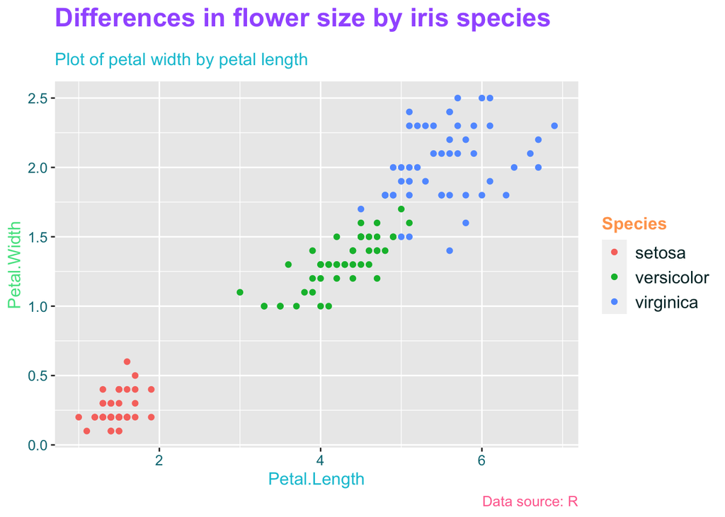

```r
# Colours
  dark_green <- "#002D30"
  light_grey <- "#F2F2F2"
  green_blue <- "#007883"
  light_green <- "#4FE18F"
  blue <- "#00C3D6"
  pink <- "#FF709D"
  purple <- "#A361FF"
  orange <- "#ffa45a"
# Font
# font <- "Derailed"

# The plot
ggplot(data = iris) +
  geom_point(mapping = aes(x = Petal.Length, y = Petal.Width, colour = Species)) +
  labs(title = "Differences in flower size by iris species",
       subtitle = "Plot of petal width by petal length",
       caption = "Data source: R") +

  # Theme
  theme(
    # Title text format:
    # Set the font family and font colour
    #text = element_text(family=font,
    #                    color=purple),

    # Make additional changes (e.g., size, type, margins) to the plot's title, subtitle and caption and the legend title and text here.
    plot.title = element_text(size=18,
                              face="bold",
                              colour = purple
                              ),

    plot.subtitle = element_text(size=12,
                                 margin=margin(9,0,9,0),
                                 colour = blue
                                 ),

    plot.caption = element_text(size=10,
                                colour = pink),

    # Legend text format:
    legend.title = element_text(size=12,
                                face = "bold",
                                colour = orange),

    legend.text = element_text(size=12,
                               colour = dark_green),

    # Axis text format:
    axis.title.y = element_text(size=12,
                              colour = light_green),
    axis.title.x = element_text(size=12,
                              colour = blue),
    # SET AS BLANK?

    # Notice that the font is pulled through in the text hierarchy but colour is not for axis.text or strip.text
    axis.text = element_text(size=10,
                             colour = green_blue),

    # Strip text
    strip.text = element_text(size=12,
                              hjust = 0,
                              colour = orange)
    )
```

### Exercise

For this exercise we will work with the following example plot.

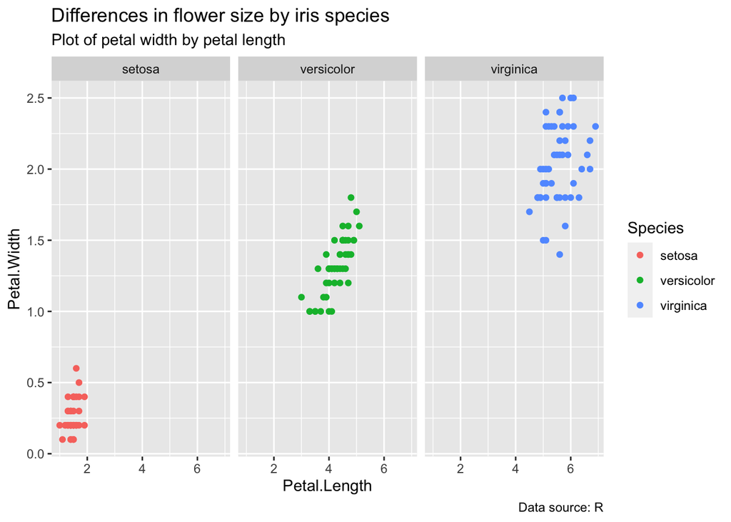

```r
ggplot(data = iris) +
  geom_point(mapping = aes(x = Petal.Length, y = Petal.Width, colour = Species)) +
  facet_grid(cols = vars(Species)) +
  labs(title = "Differences in flower size by iris species",
       subtitle = "Plot of petal width by petal length",
       caption = "Data source: R")
```

Task:

- Review the [`theme()` documentation](https://ggplot2.tidyverse.org/reference/theme.html)
- Update the theme in the code chunk below

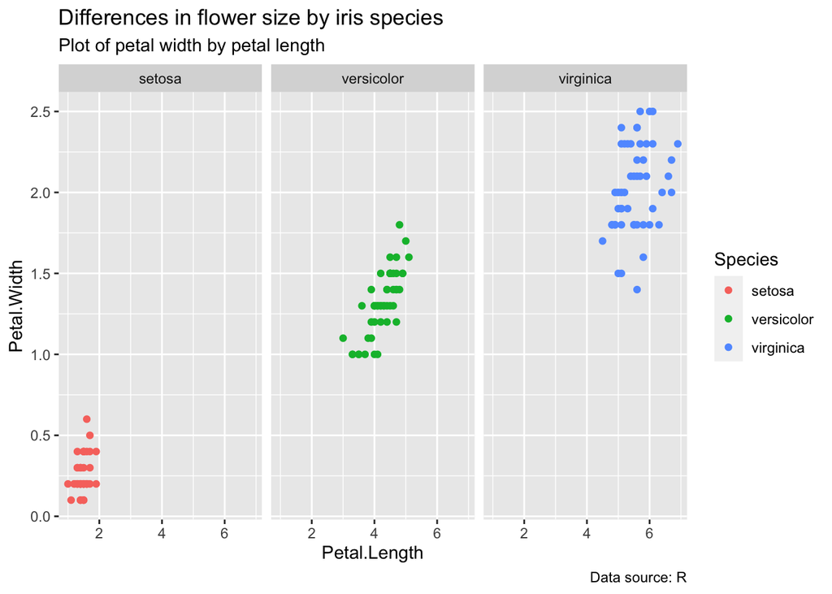

```r
ggplot(data = iris) +
  geom_point(mapping = aes(x = Petal.Length, y = Petal.Width, colour = Species)) +
  facet_grid(cols = vars(Species)) +
  labs(title = "Differences in flower size by iris species",
       subtitle = "Plot of petal width by petal length",
       caption = "Data source: R") +
  theme(

    # RECTANGLES
    # element_rect()
    #plot.background = element_rect(),
    #panel.background = element_rect(),

    #legend.key = element_rect(),
    #legend.background = element_rect(),
    #legend.margin = margin(),
    #legend.position(),
    #legend.direction(),
    #legend.justification(),

    #legend.box.background = element_rect(),
    #legend.box.margin = margin(),

    #panel.spacing(),

    # LINES
    #axis.ticks = element_line(),
    #axis.ticks.length = unit(.5, "cm"),

    #axis.line = element_line()
    #axis.line.x = element_line(),
    #axis.line.y = element_line(),

    #panel.grid = element_line(),
    #panel.grid.minor = element_line(),
    #panel.grid.major = element_line(),

    # TEXT
    #text = element_text(),
    #plot.title = element_text(),
    #plot.subtitle = element_text(),
    #plot.caption = element_text(),

    #legend.title = element_text(),
    #legend.title.align(),
    #legend.text = element_text(),
    #legend.text.align(),


    #axis.title = element_text(),
    #axis.title.y = element_text(),
    #axis.title.x = element_text(),

    #axis.text = element_text(),

    #strip.text = element_text()

    )
```